# Data Manipulation in R

Data Manipulation Objectives:

- Learn how to summarize data efficiently
- Understand how to convert between wide form and long form data as well as the uses for each type of data
- Recognize “tidy” data and use `tidyr` and `dplyr` functions to work towards “tidy” data
- Understand how to work with dates and times in R

# Reading in Data

## Setup

```r
# Setup.R file
source("https://bit.ly/2i8sicn")
```

## Data in Excel

Formats xlsx and csv - what’s the difference?

- File extensions xls and xlsx are proprietary Excel formats, binary files
- csv is an extension for Comma Separated Value files. They are text files - directly readable.
- Example: Gas prices in midwest since 1994

### Gas Prices in the Midwest

```r
midwest <- read.csv("https://bit.ly/2hwWiQ8")
head(midwest)
```

```
##   Year.Month   Week.1     X   Week.2   X.1   Week.3   X.2   Week.4   X.3
## 1            End Date Value End Date Value End Date Value End Date Value
## 2   1994-Nov                                                28-Nov 1.122
## 3   1994-Dec    5-Dec 1.086   12-Dec 1.057   19-Dec 1.039   26-Dec 1.027
## 4   1995-Jan    2-Jan 1.025    9-Jan 1.046   16-Jan 1.031   23-Jan 1.054
## 5   1995-Feb    6-Feb 1.045   13-Feb  1.04   20-Feb 1.031   27-Feb 1.052
## 6   1995-Mar    6-Mar 1.053   13-Mar 1.042   20-Mar 1.048   27-Mar 1.065
##     Week.5   X.4
## 1 End Date Value
## 2
## 3
## 4   30-Jan 1.055
## 5
## 6
```

```r
str(midwest)
```

```
## 'data.frame':    212 obs. of  11 variables:
##  $ Year.Month: Factor w/ 212 levels "","1994-Dec",..: 1 3 2 8 7 11 4 12 10 9 ...
##  $ Week.1    : Factor w/ 86 levels "","1-Apr","1-Aug",..: 86 1 52 18 65 69 26 10 56 31 ...
##  $ X         : Factor w/ 197 levels "","0.905","0.918",..: 197 1 19 7 12 13 21 29 42 31 ...
##  $ Week.2    : Factor w/ 86 levels "","10-Apr","10-Aug",..: 86 1 28 78 41 45 2 70 32 7 ...
##  $ X.1       : Factor w/ 206 levels "","0.919","0.921",..: 206 1 17 14 12 13 27 39 45 34 ...
##  $ Week.3    : Factor w/ 86 levels "","15-Apr","15-Aug",..: 86 1 52 18 65 69 26 10 56 31 ...
##  $ X.2       : Factor w/ 199 levels "","0.91","0.929",..: 199 1 11 9 9 15 28 40 38 29 ...
##  $ Week.4    : Factor w/ 85 levels "22-Apr","22-Aug",..: 85 82 51 17 64 68 25 9 55 30 ...
##  $ X.3       : Factor w/ 201 levels "0.883","0.921",..: 201 29 9 14 13 15 32 44 34 27 ...
##  $ Week.5    : Factor w/ 31 levels "","29-Apr","29-Aug",..: 31 1 1 16 1 1 1 9 1 27 ...
##  $ X.4       : Factor w/ 74 levels "","0.955","1.023",..: 74 1 1 5 1 1 1 18 1 11 ...
```

The variables are all factors, which are numeric variables with labels. Instead, they should be character and numeric variables. In addition, the first row is made up of labels, rather than actual data.

There is clearly some work to be done…

`read.csv` is really just a wrapper for `read.table` with certain parameters set:

```r
read.csv
## function (file, header = TRUE, sep = ",", quote = "\"", dec = ".",
##     fill = TRUE, comment.char = "", ...)
## read.table(file = file, header = header, sep = sep, quote = quote,
##     dec = dec, fill = fill, comment.char = comment.char, ...)
## <bytecode: 0x00000000128650f8>
## <environment: namespace:utils>
```

So to properly read in this data, it’s probably best to use `read.table` directly

```r
?read.table
```

##### Your Turn

Have a look at the parameters of read.table (?read.table) to solve the following problems:

1. Read the first two lines of the file into an object called `midwest_names`
2. Read everything EXCEPT the first two lines into an object called `midwest_data`

##### Solutions

1. Read the first two lines of the file into an object called `midwest_names`

```r
midwest_names <- read.table("https://bit.ly/2hwWiQ8",
                            nrows = 2, sep = ",",
                            stringsAsFactors = FALSE)
```

2. Read everything EXCEPT the first two lines into an object called `midwest_data`

```r
midwest_data <- read.table("https://bit.ly/2hwWiQ8",
                           skip = 2, sep = ",",
                           stringsAsFactors = FALSE)
```

## Demo: Data Cleaning

In order to demonstrate reading data in to R, some quick data cleaning is necessary.

First, all of the gas prices are collected in the `values` variable.

```r
values <- c(midwest_data$V3, midwest_data$V5, midwest_data$V7,
            midwest_data$V9, midwest_data$V11)
```

Then, all of the dates are collected in the dates variable, with the year, month, and end date pasted together separated by “-”.

```r
dates <- c(paste(midwest_data$V1, midwest_data$V2, sep = "-"),
           paste(midwest_data$V1, midwest_data$V4, sep = "-"),
           paste(midwest_data$V1, midwest_data$V6, sep = "-"),
           paste(midwest_data$V1, midwest_data$V8, sep = "-"),
           paste(midwest_data$V1, midwest_data$V10, sep = "-"))
```

Missing/empty values are then removed from both variables.

```r
dates <- dates[!is.na(values)]
values <- values[!is.na(values)]
```

Finally, the dates are converted to `Date` variable types using the `ymd` function (more on this later). The `dates` and `price` variables (the `values` collected above) are combined into a data frame and then ordered chronologically.

```r
library(lubridate)
dates <- ymd(dates)

midwest_gas <- data.frame(date = dates, price = values)
midwest_gas <- midwest_gas[with(midwest_gas, order(date)), ]
```

A simpler way to reorganize data structured like this will be shown later.

With the tidy version of the midwest gas dataset constructed, it is fairly easy to plot the data:

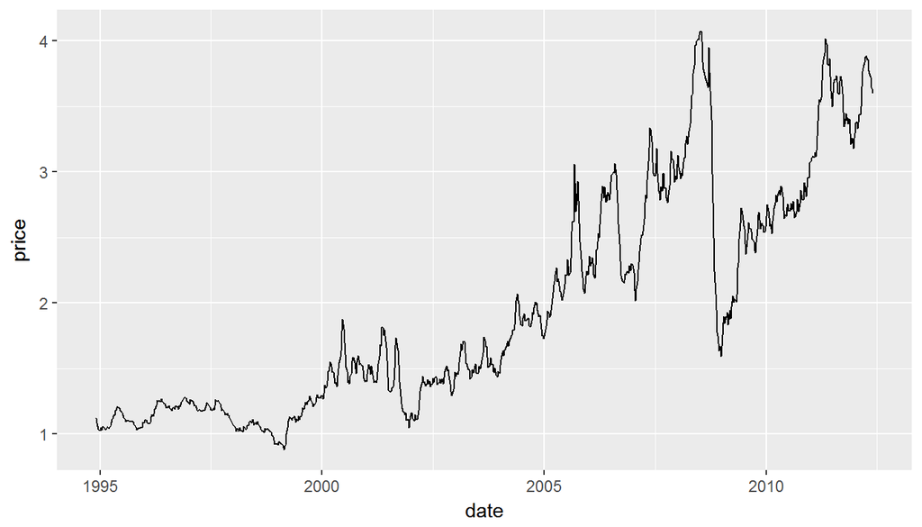

```r
library(ggplot2)
qplot(date, price, data = midwest_gas, geom = "line")
```

## Reading Excel Data

```r
library(readxl)
download.file(url = "https://bit.ly/2i6oyFi",
              destfile = "midwest.xlsx",
              mode = "wb")

midwest2 <- read_excel("midwest.xlsx")
# Fix name issues
names(midwest2) <- make.names(names(midwest2))
head(midwest2, 4)
```

```
## # A tibble: 4 × 11
##   Year.Month   Week.1                  X   Week.2                  X
##        <chr>    <chr>              <chr>    <chr>              <chr>
## 1       <NA> End Date              Value End Date              Value
## 2   1994-Nov     <NA>               <NA>     <NA>               <NA>
## 3   1994-Dec    43074 1.0860000000000001    43081 1.0569999999999999
## 4   1995-Jan    42737 1.0249999999999999    42744              1.046
## # ... with 6 more variables: Week.3 <chr>, X <chr>, Week.4 <chr>, X <chr>,
## #   Week.5 <chr>, X <chr>
```

## `foreign` Package

Other file formats can be read using the functions from package `foreign`

- SPSS: `read.spss`
- SAS: `read.xport`
- Minitab: `read.mtp`

##### Your Turn

The NHANES (National Health and Nutrition Survey) publishes data in the SAS xport format:

https://wwwn.cdc.gov/Nchs/Nhanes/Search/nhanes13_14.aspx

1. Scroll to the bottom, choose one of the datasets (Demographics, Examination, etc.). Download the Data file (XPT)
2. Use `read.xport()` to load the file into R

##### Solutions

```r
download.file("https://wwwn.cdc.gov/Nchs/Nhanes/2013-2014/DEMO_H.XPT",
              destfile = "DEMO.XPT", mode = "wb")
library(foreign)
demographic.vars <- read.xport("DEMO.XPT")
```

# Summarizing Data

## Baseball Data

- The `plyr` package contains the data set `baseball`
- seasonal batting statistics of all major league players (through 2007)

```r
data(baseball, package = "plyr")
help(baseball, package = "plyr")
## starting httpd help server ...
##  done
head(baseball)
```

```
##            id year stint team lg  g  ab  r  h X2b X3b hr rbi sb cs bb so
## 4   ansonca01 1871     1  RC1    25 120 29 39  11   3  0  16  6  2  2  1
## 44  forceda01 1871     1  WS3    32 162 45 45   9   4  0  29  8  0  4  0
## 68  mathebo01 1871     1  FW1    19  89 15 24   3   1  0  10  2  1  2  0
## 99  startjo01 1871     1  NY2    33 161 35 58   5   1  1  34  4  2  3  0
## 102 suttoez01 1871     1  CL1    29 128 35 45   3   7  3  23  3  1  1  0
## 106 whitede01 1871     1  CL1    29 146 40 47   6   5  1  21  2  2  4  1
##     ibb hbp sh sf gidp
## 4    NA  NA NA NA   NA
## 44   NA  NA NA NA   NA
## 68   NA  NA NA NA   NA
## 99   NA  NA NA NA   NA
## 102  NA  NA NA NA   NA
## 106  NA  NA NA NA   NA
```

- Goal: create career summary statistics for each player
- Plan: subset on a player, and compute statistics

```r
ss <- subset(baseball, id == "sosasa01")
head(ss, 3)
```

```
##             id year stint team lg   g  ab  r   h X2b X3b hr rbi sb cs bb
## 66822 sosasa01 1989     1  TEX AL  25  84  8  20   3   0  1   3  0  2  0
## 66823 sosasa01 1989     2  CHA AL  33  99 19  27   5   0  3  10  7  3 11
## 67907 sosasa01 1990     1  CHA AL 153 532 72 124  26  10 15  70 32 16 33
##        so ibb hbp sh sf gidp
## 66822  20   0   0  4  0    3
## 66823  27   2   2  1  2    3
## 67907 150   4   6  2  6   10
```

```r
mean(ss$h / ss$ab)
```

```
## [1] 0.2681506
```

There should be an **automatic** way to calculate this.

## `for` loops

- Idea: repeat the same (set of) statement(s) for each element of an index set
- Setup:
  - Introduce counter variable (sometimes named `i`)
  - Reserve space for results
- Generic Code:

```r
result <- rep(NA, length(indexset))
for (i in indexset) {
  ... some statements ...
  result[i] <- ...
}
```

### `for` loops for Baseball

- Index set: player id
- Setup:

```r
players <- unique(baseball$id)
n <- length(players)

ba <- rep(NA, n)

for (i in 1:n) {
  career <- subset(baseball, id == players[i])
  ba[i] <- with(career, mean(h / ab, na.rm = TRUE))
}

summary(ba)
```

```
##    Min. 1st Qu.  Median    Mean 3rd Qu.    Max.    NA's
##  0.0000  0.1831  0.2459  0.2231  0.2699  0.5000       6
```

- Index set: player id
- `i = 0`:

```r
players <- unique(baseball$id)
n <- length(players)

ba <- rep(NA, n)

head(ba)
```

```
## [1] NA NA NA NA NA NA
```

- Index set: player id
- `i = 1`:

```r
players <- unique(baseball$id)

ba <- rep(NA, length(players))

for (i in 1:1) {
  career <- subset(baseball, id == players[i])
  ba[i] <- with(career, mean(h / ab, na.rm = TRUE))
}

head(ba)
```

```
## [1] 0.3371163        NA        NA        NA        NA        NA
```

- Index set: player id
- `i = 2`:

```r
players <- unique(baseball$id)

ba <- rep(NA, length(players))

for (i in 1:2) {
  career <- subset(baseball, id == players[i])
  ba[i] <- with(career, mean(h / ab, na.rm = TRUE))
}

head(ba)
```

```
## [1] 0.3371163 0.2489226        NA        NA        NA        NA
```

- Index set: player id
- `i = 3`:

```r
players <- unique(baseball$id)

ba <- rep(NA, length(players))

for (i in 1:3) {
  career <- subset(baseball, id == players[i])
  ba[i] <- with(career, mean(h / ab, na.rm = TRUE))
}

head(ba)
```

```
## [1] 0.3371163 0.2489226 0.2018073        NA        NA        NA
```

##### Your Turn

- MLB rules for the greatest all-time hitters are that players have to have played
  - at least 1000 games
  - with at least 1000 at-bats in order to be considered
- Extend the for loop above to collect the additional information
- Introduce and collect data for two new variables: `games` and `atbats`

### Solution

```r
library(dplyr)
data(baseball, package = "plyr")


players <- unique(baseball$id)
ba <- rep(NA, length(players))
games <- rep(NA, length(players))
atbats <- rep(NA, length(players))
for (i in 1:length(players)) {
  career <- subset(baseball, id == players[i])
  ba[i] <- with(career, mean(h / ab, na.rm = TRUE))
  games[i] <- with(career, sum(g, na.rm = TRUE))
  atbats[i] <- with(career, sum(ab, na.rm = TRUE))
}
```

Using `for`loops can be difficult and tedious. - Household chores (declaring variables, setting values each time) distract from real work - Indices are error-prone - Loops often result in slow code because R can compute quantities using entire vectors in an optimized way

Fortunately, R makes this process much easier with the `summarize` function

## Summarize

A special function: `summarise` or `summarize`

This function takes a data frame worth of data and computes summary functions using the entire data frame.

```r
library(dplyr)

baseball <- read.csv("https://bit.ly/2iFyIwL")

summarize(baseball,
          ba = mean(h / ab, na.rm = TRUE),
          games = sum(g, na.rm = TRUE),
          hr = sum(hr, na.rm = TRUE),
          ab = sum(ab, na.rm = TRUE))
```

```
##          ba   games     hr      ab
## 1 0.2339838 1580070 113577 4891061
```

When passed a subset of the data, the `summarize` function computes statistics for only that portion of the data frame.

```r
summarize(subset(baseball, id == "sosasa01"),
          ba = mean(h / ab, na.rm = TRUE),
          games = sum(g, na.rm = TRUE),
          hr = sum(hr, na.rm = TRUE),
          ab = sum(ab, na.rm = TRUE))
```

```
##          ba games  hr   ab
## 1 0.2681506  2354 609 8813
```

## `dplyr` + `Summarize`

The `dplyr` package facilitates splitting the dataset into sub-datasets (groups), applying functions to those sub-groups, and then recombining the function results into a new dataset. This process is very powerful when creating summary statistics.

```r
careers <- summarize(group_by(baseball, id),
                 ba = mean(h / ab, na.rm = TRUE),
                 games = sum(g, na.rm = TRUE),
                 homeruns = sum(hr, na.rm = TRUE),
                 atbats = sum(ab, na.rm = TRUE))

head(careers)
```

```
## # A tibble: 6 × 5
##          id        ba games homeruns atbats
##      <fctr>     <dbl> <int>    <int>  <int>
## 1 aaronha01 0.3010752  3298      755  12364
## 2 abernte02 0.1824394   681        0    181
## 3 adairje01 0.2363071  1165       57   4019
## 4 adamsba01 0.2096513   482        3   1019
## 5 adamsbo03 0.2378073  1281       37   4019
## 6 adcocjo01 0.2751690  1959      336   6606
```

## Pipes

Rather than nesting functions(inside(each(other))), use a pipe `%>%`:

```r
careers <- baseball %>%
  group_by(id) %>%
  summarize(
    ba = mean(h / ab, na.rm = TRUE),
    games = sum(g, na.rm = TRUE),
    homeruns = sum(hr, na.rm = TRUE),
    atbats = sum(ab, na.rm = TRUE)
  )
```

Pipes make code more readable and easier to understand.

`a %>% function(b)`  
is the same as  
`function(a, b)`:

the piped variable is substituted for the first function argument.

If the argument passed in is not the first argument, use `.`:  
`b %>% function(a, .)`  
is the same as  
`function(a, b)`

##### Your Turn

- Find some summary statistics for each of the teams (variable `team`)
  - How many different (`unique`) players has the team had?
  - What was the team’s first/last season?
- Challenge: Find the number of players on each team over time. Does the number change?

##### Solutions

1. Find some summary stats for each of the teams (`team`)
   - How many `unique` players has the team had?
   - What was the team’s first/last season?

```r
baseball %>%
  group_by(team) %>%
  summarize(
    nplayer = length(unique(id)),
    first = min(year),
    last = max(year))
```

```
## # A tibble: 132 × 4
##      team nplayer first  last
##    <fctr>   <int> <int> <int>
## 1     ALT       1  1884  1884
## 2     ANA      29  1997  2004
## 3     ARI      43  1998  2007
## 4     ATL     133  1966  2007
## 5     BAL     158  1954  2007
## 6     BFN      11  1879  1885
## 7     BFP       1  1890  1890
## 8     BL1       5  1872  1874
## 9     BL2       6  1882  1889
## 10    BL3       3  1890  1891
## # ... with 122 more rows
```

2. Challenge: Find the number of players on each team over time. Does the number change?

[figure not shown]

```r
players.per.year <- baseball %>%
  group_by(team, year) %>%
  summarize(nplayer = n())
## `geom_smooth()` using method = 'gam'
```

# Transforming and Analyzing Data

## Data Housekeeping

80% of data analysis is spent on the process of cleaning and preparing the data.

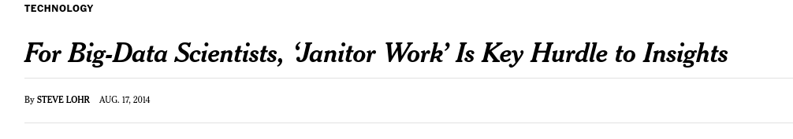

“Tidy datasets are all alike but every messy dataset is messy in its own way.” – Hadley Wickham

### French Fries Data

During a ten week sensory experiment, 12 individuals were asked to assess taste of french fries on several scales:

How ____ do the fries taste?

- potato-y
- buttery
- grassy
- rancid
- paint-y

This experiment involved

- 3 different oils
- 2 replicates
- 12 individuals
- 10 weeks
- 5 qualities to rate

Each week, each individual tasted 6 batches of french fries.

```r
french_fries <- read.csv("https://bit.ly/2hOI890")
head(french_fries)
```

```
##   time treatment subject rep potato buttery grassy rancid painty
## 1    1         1       3   1    2.9     0.0    0.0    0.0    5.5
## 2    1         1       3   2   14.0     0.0    0.0    1.1    0.0
## 3    1         1      10   1   11.0     6.4    0.0    0.0    0.0
## 4    1         1      10   2    9.9     5.9    2.9    2.2    0.0
## 5    1         1      15   1    1.2     0.1    0.0    1.1    5.1
## 6    1         1      15   2    8.8     3.0    3.6    1.5    2.3
```

#### Issues

This format is not ideal for data analysis

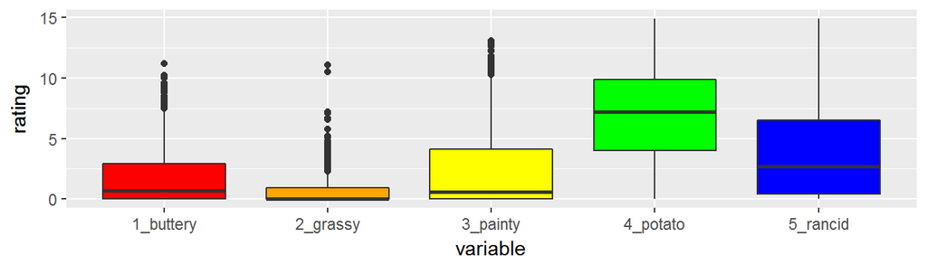

```r
library(ggplot2)

qplot("1_buttery", buttery, data = french_fries, fill = I("red"), geom = "boxplot") +
    geom_boxplot(aes(x = "2_grassy", y = grassy), fill = I("orange")) +
    geom_boxplot(aes(x = "3_painty", y = painty), fill = I("yellow")) +
    geom_boxplot(aes(x = "4_potato", y = potato), fill = I("green")) +
    geom_boxplot(aes(x = "5_rancid", y = rancid), fill = I("blue")) +
    xlab("variable") + ylab("rating")
```

## Tidy Data

Data which follows these rules is “tidy” and easier to work with in R:

- Each variable in the data set is placed in its own column
- Each observation is placed in its own row
- Each value is placed in its own cell

### Ideal Data

The french fry data is in **wide format**

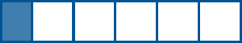

Wide Format

and should be in **long format** for plotting

This is done using the `gather` function.

### Gathering

When gathering, specify the **keys** (identifiers) and the **values** (measures).

#### Keys/Identifiers:

- Identify a record (must be unique)
- Example: Indices on an random variable
- Fixed by design of experiment (known in advance)
- May be single or composite (may have one or more variables)

#### Values/Measures:

- Collected during the experiment (not known in advance)
- Usually numeric quantities

#### French Fry Data

```r
library(tidyr)

french_fries_long <- gather(french_fries,
                            key = variable,
                            value = rating,
                            potato:painty)

head(french_fries_long)
```

```
##   time treatment subject rep variable rating
## 1    1         1       3   1   potato    2.9
## 2    1         1       3   2   potato   14.0
## 3    1         1      10   1   potato   11.0
## 4    1         1      10   2   potato    9.9
## 5    1         1      15   1   potato    1.2
## 6    1         1      15   2   potato    8.8
```

Plotting is much easier with long format data:

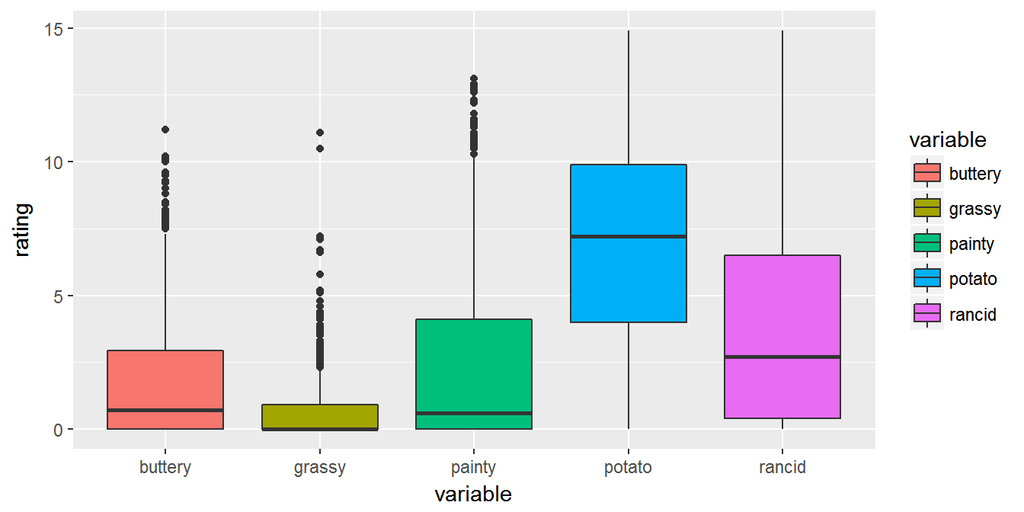

```r
qplot(variable, rating, data = french_fries_long,
      fill = variable, geom = "boxplot")
```

## Spread

In certain applications, a wide dataset may be preferable (e.g. to display in a table).

```r
head(french_fries_long)
```

```
##   time treatment subject rep variable rating
## 1    1         1       3   1   potato    2.9
## 2    1         1       3   2   potato   14.0
## 3    1         1      10   1   potato   11.0
## 4    1         1      10   2   potato    9.9
## 5    1         1      15   1   potato    1.2
## 6    1         1      15   2   potato    8.8
```

The `spread` function (from `tidyr`) is used to do this:

```r
french_fries_wide <- spread(french_fries_long,
                            key = variable, value = rating)

head(french_fries_wide)
```

```
##   time treatment subject rep buttery grassy painty potato rancid
## 1    1         1       3   1     0.0    0.0    5.5    2.9    0.0
## 2    1         1       3   2     0.0    0.0    0.0   14.0    1.1
## 3    1         1      10   1     6.4    0.0    0.0   11.0    0.0
## 4    1         1      10   2     5.9    2.9    0.0    9.9    2.2
## 5    1         1      15   1     0.1    0.0    5.1    1.2    1.1
## 6    1         1      15   2     3.0    3.6    2.3    8.8    1.5
```

##### Your Turn

Read in the billboard top 100 music data

```r
billboard <- read.csv("https://bit.ly/2hQGDao")
```

1. Use `tidyr` to convert this data into a long format.
2. Use `ggplot2` to create this time series plot:

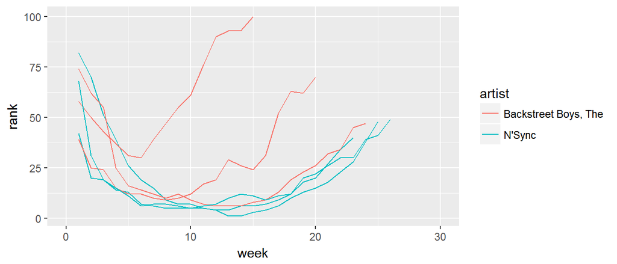

##### Solutions

1. Use `tidyr` to convert this data into a long format.

```r
long_billboard <- gather(billboard,
                         key = week, value = rank,
                         X1:X76)

# Convert weeks to numeric variables
long_billboard$week <- long_billboard$week %>%
  gsub("X", "", .) %>%
  as.numeric()

# Get rid of NAs:
long_billboard <- long_billboard %>% na.omit()
```

2. Use `ggplot2` to create this time series plot:

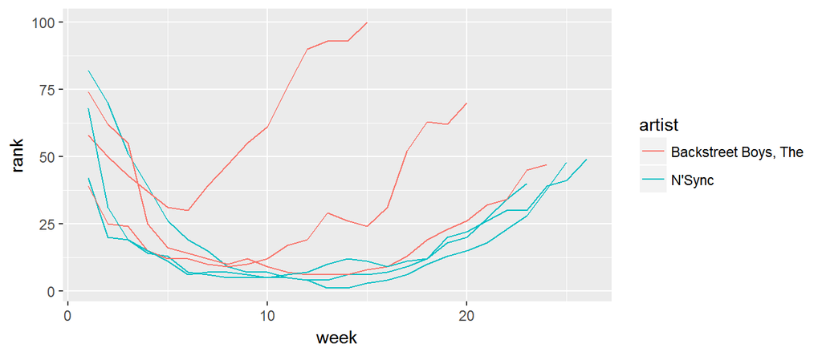

```r
qplot(x = week, y = rank,
      colour = artist, group = track,
      data = long_billboard, geom = "line")
```

## Split-Apply-Combine

- *Split* a dataset into many smaller sub-datasets
- *Apply* some function to each sub-dataset
- *Combine* the results of the function calls  
  into one dataset

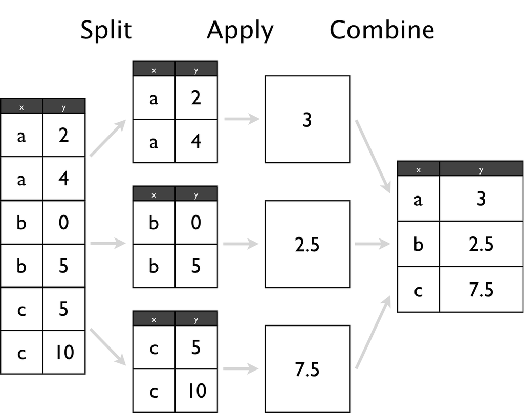

### Using `dplyr`

```r
library(dplyr)

french_fries_rating <- french_fries_long %>%
  # SPLIT:
  group_by(variable) %>%
  # APPLY + COMBINE:
  summarize(rating = mean(rating, na.rm = T))

french_fries_rating
```

```
## # A tibble: 5 × 2
##   variable    rating
##      <chr>     <dbl>
## 1  buttery 1.8236994
## 2   grassy 0.6641727
## 3   painty 2.5217579
## 4   potato 6.9525180
## 5   rancid 3.8522302
```

## `dplyr` verbs

There are five primary `dplyr` **verbs**, representing distinct data analysis tasks:

- `filter`: Keep only a subset of a data frame
- `arrange`: Reorder the rows of a data frame
- `select`: Select particular columns of a data frame
- `mutate`: Add new columns computed from existing cols
- `summarize`: Create collapsed summaries of a data frame

### Filter

```r
french_fries %>%
  filter(subject == 3, time == 1)
```

```
##   time treatment subject rep potato buttery grassy rancid painty
## 1    1         1       3   1    2.9     0.0    0.0    0.0    5.5
## 2    1         1       3   2   14.0     0.0    0.0    1.1    0.0
## 3    1         2       3   1   13.9     0.0    0.0    3.9    0.0
## 4    1         2       3   2   13.4     0.1    0.0    1.5    0.0
## 5    1         3       3   1   14.1     0.0    0.0    1.1    0.0
## 6    1         3       3   2    9.5     0.0    0.6    2.8    0.0
```

### Arrange

```r
french_fries %>%
  arrange(desc(rancid)) %>%
  head
```

```
##   time treatment subject rep potato buttery grassy rancid painty
## 1    9         2      51   1    7.3     2.3      0   14.9    0.1
## 2   10         1      86   2    0.7     0.0      0   14.3   13.1
## 3    5         2      63   1    4.4     0.0      0   13.8    0.6
## 4    9         2      63   1    1.8     0.0      0   13.7   12.3
## 5    5         2      19   2    5.5     4.7      0   13.4    4.6
## 6    4         3      63   1    5.6     0.0      0   13.3    4.4
```

### Select

```r
french_fries %>%
  select(time, treatment, subject, rep, potato) %>%
  head
```

```
##   time treatment subject rep potato
## 1    1         1       3   1    2.9
## 2    1         1       3   2   14.0
## 3    1         1      10   1   11.0
## 4    1         1      10   2    9.9
## 5    1         1      15   1    1.2
## 6    1         1      15   2    8.8
```

### Mutate

```r
french_fries %>%
  mutate(rancid2 = rancid^2) %>%
  select(time, treatment, subject, rancid, rancid2) %>%
  head
```

```
##   time treatment subject rancid rancid2
## 1    1         1       3    0.0    0.00
## 2    1         1       3    1.1    1.21
## 3    1         1      10    0.0    0.00
## 4    1         1      10    2.2    4.84
## 5    1         1      15    1.1    1.21
## 6    1         1      15    1.5    2.25
```

### Summarize

```r
french_fries %>%
    group_by(time, treatment) %>%
    summarize(mean_rancid = mean(rancid),
              sd_rancid = sd(rancid))
## Source: local data frame [30 x 4]
## Groups: time [?]
##
##     time treatment mean_rancid sd_rancid
##    <int>     <int>       <dbl>     <dbl>
## 1      1         1    2.758333  3.212870
## 2      1         2    1.716667  2.714801
## 3      1         3    2.600000  3.202037
## 4      2         1    3.900000  4.374730
## 5      2         2    2.141667  3.117540
## 6      2         3    2.495833  3.378767
## 7      3         1    4.650000  3.933358
## 8      3         2    2.895833  3.773532
## 9      3         3    3.600000  3.592867
## 10     4         1    2.079167  2.394737
## # ... with 20 more rows
```

##### Your Turn

This dataset contains information on over 300,000 flights that departed from New York City in the year 2013.

```r
flights <- read.csv("https://bit.ly/2hzhAfW")
```

1. Using `dplyr` and the pipe operator (`%>%`), create a data frame consisting of the average arrival delay (`arr_delay`) based on the destination airport (`dest`).  
   Sort this data frame in descending order, so the destination airport with the largest delay is first.
2. Find out the most used airports for each airline carrier.

##### Solutions

1. Create a data frame consisting of the average arrival delay (`arr_delay`) based on the destination airport (`dest`).  
   Sort this data frame in descending order, so the destination airport with the largest delay is first.

```r
flights %>%
  group_by(dest) %>%
  summarize(avg_delay = mean(na.omit(arr_delay))) %>%
  arrange(desc(avg_delay))
```

```
## # A tibble: 105 × 2
##      dest avg_delay
##    <fctr>     <dbl>
## 1     CAE  41.76415
## 2     TUL  33.65986
## 3     OKC  30.61905
## 4     JAC  28.09524
## 5     TYS  24.06920
## 6     MSN  20.19604
## 7     RIC  20.11125
## 8     CAK  19.69834
## 9     DSM  19.00574
## 10    GRR  18.18956
## # ... with 95 more rows
```

2. Find out the most used airports for each airline carrier.

```r
by.origin <- flights %>%
  group_by(carrier, origin) %>%
  summarize(count = n()) %>%
  ungroup() %>% group_by(carrier) %>%
  filter(count == max(count)) %>%
  rename(mostused = origin) %>%
  mutate(kind = "origin")

by.dest <- flights %>%
  group_by(carrier, dest) %>%
  summarize(count = n()) %>%
  ungroup() %>% group_by(carrier) %>%
  filter(count == max(count)) %>%
  rename(mostused = dest) %>%
  mutate(kind = "dest")

mostused <- bind_rows(by.origin,by.dest)
mostused %>% group_by(carrier) %>%
  filter(count == max(count)) %>% ungroup() %>%
  arrange(desc(count))
```

```
## # A tibble: 19 × 4
##    carrier mostused count   kind
##     <fctr>    <chr> <int>  <chr>
## 1       UA      EWR 46087 origin
## 2       EV      EWR 43939 origin
## 3       B6      JFK 42076 origin
## 4       DL      LGA 23067 origin
## 5       MQ      LGA 16928 origin
## 6       AA      LGA 15459 origin
## 7       9E      JFK 14651 origin
## 8       US      LGA 13136 origin
## 9       WN      EWR  6188 origin
## 10      VX      JFK  3596 origin
## 11      FL      LGA  3260 origin
## 12      AS      EWR   714 origin
## 13      AS      SEA   714   dest
## 14      F9      LGA   685 origin
## 15      F9      DEN   685   dest
## 16      YV      LGA   601 origin
## 17      HA      JFK   342 origin
## 18      HA      HNL   342   dest
## 19      OO      LGA    26 origin
```

## Dates and Times

Dates are deceptively hard to work with.

**Example**: 02/05/2012. Is it February 5th, or May 2nd?

Other things are difficult too:

- Time zones
- POSIXct format in base R is challenging

The **lubridate** package helps tackle some of these issues.

### Basic Lubridate Use

```r
library(lubridate)

now()
today()
now() + hours(4)
today() - days(2)
```

```
## [1] "2017-02-23 08:16:30 CST"
## [1] "2017-02-23"
## [1] "2017-02-23 12:16:30 CST"
## [1] "2017-02-21"
```

### Parsing Dates

```r
ymd("2013-05-14")
mdy("05/14/2013")
dmy("14052013")
ymd_hms("2013:05:14 14:50:30", tz = "America/Chicago")
```

```
## [1] "2013-05-14"
## [1] "2013-05-14"
## [1] "2013-05-14"
## [1] "2013-05-14 14:50:30 CDT"
```

##### Your Turn

1. Using the `flights` data, create a new column Date using lubridate. Paste together the columns year, month, and day in order to do this. See the `paste` function.
2. Use `dplyr` to calculate the average departure delay for each date.
3. Plot the date versus the average departure delay

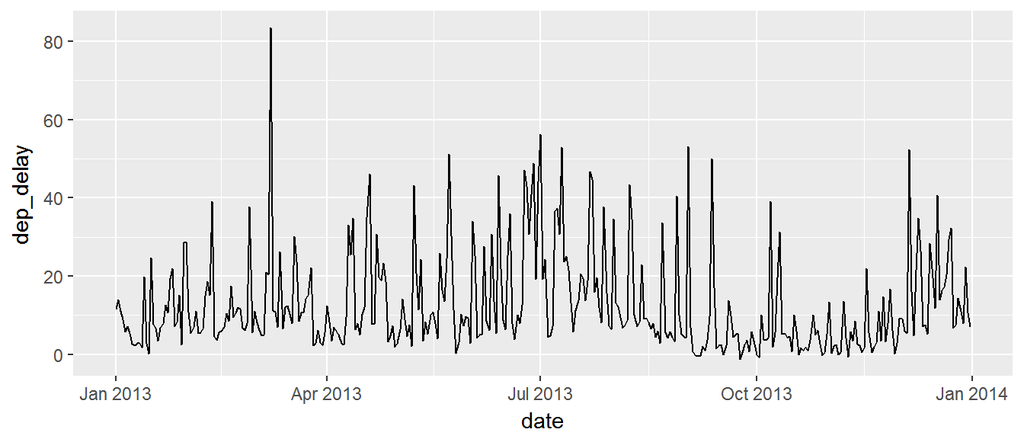

##### Solutions

1. Using the `flights` data, create a new column Date using lubridate.

```r
flights$date <- paste(flights$year, flights$month, flights$day,
                      sep = "-") %>%
  ymd() # Convert from character to date format
```

2. Use `dplyr` to calculate the average departure delay for each date.

```r
delay.dat <- flights %>%
    group_by(date) %>%
    summarize(dep_delay = mean(dep_delay, na.rm = TRUE))
```

3. Plot the date versus the average departure delay

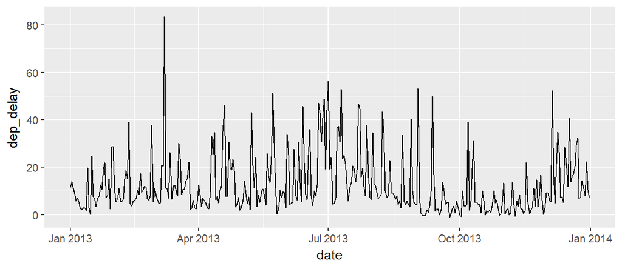

```r
qplot(date, dep_delay, geom = "line", data = delay.dat)
```